# **Tugas-Pertemuan-3**

Elardian Putera Ramadhan (G1401231042)

2025-09-01

## *Packages*

```r
library(dLagM)
library(dynlm)
library(MLmetrics)
library(lmtest)
library(car)
```

## **Import Data**

```r
raw_data <- read.csv("C:/Users/Putera Ramadhan/OneDrive/Documents/IPB University/Semester 5/(MPDW) Metode Peramalan Deret Waktu/UTS/Praktikum/MPDW/Pertemuan 3/NewDelhi_Air_quality.csv")

# Memilih kolom, mengganti nama, dan membersihkan data
data_delhi <- data.frame(
  Yt = raw_data$AQI,
  Xt = raw_data$pm25
)
data <- na.omit(data_delhi)

str(data)
```

```
## 'data.frame':    72 obs. of  2 variables:
##  $ Yt: num  30.2 28.2 26.6 25 26 26 26 24 23 24 ...
##  $ Xt: num  5.64 4.62 3.52 2.23 1.98 ...
```

```r
data
```

```
##      Yt       Xt
## 1  30.2 5.637410
## 2  28.2 4.618169
## 3  26.6 3.520902
## 4  25.0 2.225919
## 5  26.0 1.979471
## 6  26.0 1.792677
## 7  26.0 1.752237
## 8  24.0 1.858459
## 9  23.0 2.208076
## 10 24.0 2.476681
## 11 25.0 2.585729
## 12 26.0 2.390081
## 13 27.0 2.086022
## 14 29.0 1.937047
```

[output cut: 58 more lines]

## **Pembagian Data**

Data dibagi menjadi 80% data latih (`train`) dan 20% data uji (`test`).

```r
# Split Data
train_size <- floor(0.80 * nrow(data))
train <- data[1:train_size, ]
test <- data[(train_size + 1):nrow(data), ]

cat("Jumlah data latih:", nrow(train), "\n")
```

```
## Jumlah data latih: 57
```

```r
cat("Jumlah data uji:", nrow(test), "\n")
```

```
## Jumlah data uji: 15
```

```r
# Konversi ke objek time series
train.ts <- ts(train)
test.ts <- ts(test)
```

## **Model Koyck**

Model Koyck didasarkan pada asumsi bahwa semakin jauh jarak lag peubah independen dari periode sekarang maka semakin kecil pengaruh peubah lag terhadap peubah dependen.

Koyck mengusulkan suatu metode untuk menduga model dinamis distributed lag dengan mengasumsikan bahwa semua koefisien $\beta$ mempunyai tanda sama.

Model kyock merupakan jenis paling umum dari model infinite distributed lag dan juga dikenal sebagai geometric lag

$$y_t=a(1-\lambda)+\beta_0X_t+\beta_1Z_t+\lambda Y_{t-1}+V_t$$

dengan
$$V_t=u_t-\lambda
u_{t-1}$$

### **Pemodelan**

Pemodelan model Koyck dengan `R` dapat menggunakan `dLagM::koyckDlm()` . Fungsi umum dari `koyckDlm` adalah sebagai berikut.

```
koyckDlm(x , y , intercept)
```

Fungsi `koyckDlm()` akan menerapkan model lag terdistribusi dengan transformasi Koyck satu prediktor. Nilai `x` dan `y` tidak perlu sebagai objek *time series* (`ts`). `intercept` dapat dibuat `TRUE` untuk memasukkan intersep ke dalam model.

```r
model.koyck <- koyckDlm(x = train$Xt, y = train$Yt)
summary(model.koyck)
```

```
##
## Call:
## "Y ~ (Intercept) + Y.1 + X.t"
##
## Residuals:
##      Min       1Q   Median       3Q      Max
## -2.19768 -0.57669 -0.03615  0.58158  2.18318
##
## Coefficients:
##             Estimate Std. Error t value Pr(>|t|)
## (Intercept)  4.54910    1.77579   2.562   0.0133 *
## Y.1          0.87326    0.05731  15.237   <2e-16 ***
## X.t         -0.56825    0.27658  -2.055   0.0449 *
## ---
## Signif. codes:  0 '***' 0.001 '**' 0.01 '*' 0.05 '.' 0.1 ' ' 1
##
## Residual standard error: 0.8986 on 53 degrees of freedom
## Multiple R-Squared: 0.8303,  Adjusted R-squared: 0.8239
## Wald test: 129.9 on 2 and 53 DF,  p-value: < 2.2e-16
##
## Diagnostic tests:
## NULL
##
##                             alpha       beta      phi
## Geometric coefficients:  35.89204 -0.5682546 0.873256
```

```r
cat("\nAIC:", AIC(model.koyck))
```

```
## [1] 151.8615
##
## AIC: 151.8615
```

```r
cat("\nBIC:", BIC(model.koyck))
```

```
## [1] 159.9629
##
## BIC: 159.9629
```

Dari hasil tersebut, didapat bahwa peubah $x_t$ dan $y_{t-1}$ memiliki nilai $P-Value < 0.05$. Hal ini menunjukkan bahwa peubah $x_t$ dan $y_{t-1}$ berpengaruh signifikan terhadap $y$. Adapun model keseluruhannya adalah sebagai berikut

$$\hat{Y_t}=4.54910-0.56825X_t+0.87326Y_{t-1}$$

### **Peramalan dan Akurasi**

Berikut adalah hasil peramalan y untuk 15 periode kedepan menggunakan model koyck

```r
h_forecast <- nrow(test)
fore.koyck <- forecast(model = model.koyck, x = test$Xt, h = h_forecast)
mape.koyck <- MAPE(fore.koyck$forecasts, test$Yt)
cat("MAPE Model Koyck (Data Uji):", mape.koyck, "\n")
```

```
## MAPE Model Koyck (Data Uji): 0.1394956
```

```r
GoF(model.koyck)
```

```
##              n       MAE         MPE       MAPE      sMAPE     MASE       MSE
## model.koyck 56 0.6708393 -0.00101664 0.02495405 0.02490925 1.048186 0.7642032
##                  MRAE   GMRAE
## model.koyck 836328982 13944.2
```

Nilai MAPE sebesar 0.1394956 (atau 13.95%) menunjukkan bahwa Model Koyck memiliki tingkat akurasi yang baik pada data uji.

## **Regression with Distributed Lag**

Pemodelan model Regression with Distributed Lag dengan `R` dapat menggunakan `dLagM::dlm()` . Fungsi umum dari `dlm` adalah sebagai berikut.

```
dlm(formula , data , x , y , q , remove )
```

Fungsi `dlm()` akan menerapkan model lag terdistribusi dengan satu atau lebih prediktor. Nilai `x` dan `y` tidak perlu sebagai objek *time series* (`ts`). $q$ adalah integer yang mewakili panjang *lag* yang terbatas.

### **Penentuan Lag Optimum**

Penentuan lag optimum dapat dilakukan dengan menggunakan fungsi `dLagM::optLag()` . Fungsi umum dari `optLag` adalah sebagai berikut.

```
optLag(x , y , maxLags , criterion)
```

Fungsi `optLag()` akan menentukan lag optimum untuk model lag terdistribusi dengan satu prediktor. Nilai `x` dan `y` tidak perlu sebagai objek *time series* (`ts`). `maxLags` adalah integer yang mewakili jumlah maksimum lag yang akan dipertimbangkan. `criterion` adalah kriteria yang digunakan untuk memilih lag optimum, yaitu “AIC”, “BIC”, atau “SIC”.

```r
finiteDLMauto(formula = Yt ~ Xt,
              data = data.frame(train), q.min = 1, q.max = 30,
              model.type = "dlm", error.type = "AIC", trace = TRUE)
```

```
##    q - k    MASE       AIC       BIC        GMRAE    MBRAE R.Adj.Sq
## 28    28 0.00000      -Inf      -Inf      0.00000  0.23214      NaN
## 29    29 0.00000      -Inf      -Inf      0.00001  0.24074      NaN
## 30    30 0.00000      -Inf      -Inf      0.00000  0.23077      NaN
## 27    27 0.03524 -79.50095 -37.46503    918.92626  0.48566  0.99726
## 26    26 0.19437  31.79494  73.38057   2403.18562  0.46629  0.95664
## 24    24 0.22274  35.04159  75.44730   2002.62180  0.43001  0.97241
## 25    25 0.23535  38.52821  79.56881   3098.35570  0.44389  0.96261
## 22    22 0.40538  65.81859 104.70229   7789.61670  0.49289  0.94493
## 23    23 0.39278  67.67428 107.35965   5207.32515  0.47676  0.93588
## 21    21 0.52019  84.85425 122.85871  11601.80249  0.51904  0.91271
## 20    20 0.61148  87.94743 124.99854  25277.80399  0.54766  0.91084
## 19    19 0.78734 101.27592 137.30282  39636.04457  0.55232  0.87949
## 18    18 0.79093 102.50936 137.44415  43596.09442  0.54709  0.88133
## 17    17 0.83289 111.87108 145.64867  35021.62655  0.80531  0.85581
```

[output cut: 47 more lines]

Berdasarkan output tersebut, lag optimum didapatkan ketika lag = 27. Selanjutnya dilakukan pemodelan untuk lag = 27

### **Pemodelan DLM dengan Lag Optimum**

```r
opt_q_dlm <- 27
model.dlm <- dlm(x = train$Xt, y = train$Yt, q = opt_q_dlm)
summary(model.dlm)
```

```
##
## Call:
## lm(formula = model.formula, data = design)
##
## Residuals:
##          1          2          3          4          5          6          7
## -0.0019089  0.0027346 -0.0034411 -0.0014318  0.0045122 -0.0069610  0.0108759
##          8          9         10         11         12         13         14
## -0.0171263  0.0120124  0.0101444 -0.0199861  0.0326809 -0.0322894 -0.0007379
##         15         16         17         18         19         20         21
##  0.0070889  0.0223903 -0.0470671  0.0304543  0.0176910 -0.0305087  0.0197407
##         22         23         24         25         26         27         28
## -0.0153639  0.0299397 -0.0491427  0.0257677  0.0170993 -0.0408345  0.0351449
##         29         30
## -0.0248571  0.0133794
##
## Coefficients:
##             Estimate Std. Error t value Pr(>|t|)
## (Intercept)  55.3132    23.3793   2.366    0.255
## x.t         -20.9551     5.4016  -3.879    0.161
## x.1          19.4559     6.0265   3.228    0.191
## x.2         -23.5544    12.1285  -1.942    0.303
## x.3          24.5065    15.7624   1.555    0.364
## x.4         -13.9293    14.3116  -0.973    0.509
## x.5          -3.4143     9.7974  -0.348    0.787
## x.6          13.3343     9.6048   1.388    0.397
## x.7          -1.4064     8.6417  -0.163    0.897
## x.8          -7.6927     8.7358  -0.881    0.540
## x.9           2.3540    10.3064   0.228    0.857
## x.10         22.2707    15.1215   1.473    0.380
## x.11        -20.5220    12.4707  -1.646    0.348
## x.12         -1.7492     6.9637  -0.251    0.843
## x.13          4.2970     9.7403   0.441    0.736
## x.14          0.7338     9.3064   0.079    0.950
## x.15         -0.5496     9.0597  -0.061    0.961
## x.16        -34.3390     9.1975  -3.734    0.167
## x.17         54.3612    14.2365   3.818    0.163
## x.18        -40.7019    10.5892  -3.844    0.162
## x.19         25.0111     9.4104   2.658    0.229
## x.20         -8.1499     8.3830  -0.972    0.509
## x.21         -6.8374     4.7536  -1.438    0.387
## x.22         11.1115     4.0319   2.756    0.222
## x.23         -8.7804     2.8366  -3.095    0.199
## x.24          1.8236     2.9401   0.620    0.647
## x.25          3.0897     1.3053   2.367    0.254
## x.26         -6.0733     1.3397  -4.533    0.138
## x.27          2.4068     0.6176   3.897    0.160
##
## Residual standard error: 0.1296 on 1 degrees of freedom
## Multiple R-squared:  0.9999, Adjusted R-squared:  0.9973
## F-statistic: 377.4 on 28 and 1 DF,  p-value: 0.04069
##
## AIC and BIC values for the model:
##         AIC       BIC
## 1 -79.50095 -37.46503
```

```r
cat("\nAIC:", AIC(model.dlm))
```

```
## [1] -79.50095
##
## AIC: -79.50095
```

```r
cat("\nBIC:", BIC(model.dlm))
```

```
## [1] -37.46503
##
## BIC: -37.46503
```

Dari hasil tersebut, tidak ada peubah individual yang berpengaruh signifikan terhadap taraf nyata 5% (α = 0.05) berdasarkan uji t. Namun, karena nilai p-value dari Uji F (0.04069) lebih kecil dari 0.05, maka dapat disimpulkan bahwa semua peubah secara bersama-sama (simultan) berpengaruh signifikan. Adapun keseluruhan model yang terbentuk adalah

$$\hat{Y_t} = 55.3132 - 20.9551X_t +
19.4559X_{t-1} - 23.5544X_{t-2} + \dots + 2.4068X_{t-27}$$

### **Peramalan dan Akurasi Model DLM**

Berikut adalah hasil peramalan y untuk 15 periode kedepan menggunakan model DLM dengan lag optimum

```r
h_forecast <- nrow(test)
fore.dlm <- forecast(model = model.dlm, x = test$Xt, h = h_forecast)
mape.dlm <- MAPE(fore.dlm$forecasts, test$Yt)
cat("MAPE Model DLM (Data Uji):", mape.dlm, "\n")
```

```
## MAPE Model DLM (Data Uji): 0.2044923
```

```r
GoF(model.dlm)
```

```
##            n        MAE           MPE         MAPE        sMAPE       MASE
## model.dlm 30 0.01944377 -7.697648e-07 0.0007334943 0.0007334207 0.03524183
##                    MSE      MRAE    GMRAE
## model.dlm 0.0005598125 111156114 918.9263
```

Berdasarkan hasil peramalan, didapatkan nilai MAPE sebesar **20.45%** untuk data uji. Hal ini menunjukkan bahwa model DLM dengan lag optimum memiliki akurasi yang **cukup baik** dalam memprediksi nilai Yt pada data uji.

## **Model Autoregressive Distributed Lag (ARDL)**

### **Penentuan Lag Optimum (p,q)**

```r
ardl_orders <- ardlBoundOrders(data = data.frame(train), ic = "AIC", formula = Yt ~ Xt, max.p=25, max.q=25)
print(ardl_orders$Stat.table)
```

```
##            q = 1     q = 2      q = 3      q = 4     q = 5      q = 6     q = 7
## p = 1  140.96343 138.54505 132.994789 123.557123 123.90746  121.40329 114.20470
## p = 2  138.30775 138.82888 133.622020 125.540552 122.61537  113.66417 110.25671
## p = 3  134.13415 134.13415 135.570313 127.540400 123.92956  109.44506 108.85286
## p = 4  118.62364 120.57981 120.579808 122.235407 118.24755  108.18873 107.94733
## p = 5  114.71656 116.67961 117.275539 117.275539 118.92580  107.57522 107.98734
## p = 6  105.13284 107.11324 106.831086 108.058500 108.05850  108.76605 109.57530
## p = 7  113.19250 114.39875 111.177720 109.694565 107.88697  107.88697 109.84485
## p = 8   99.79025 101.61094 101.741215 100.880033  99.95660  100.94338 100.94338
## p = 9   88.49074  87.80524  87.869293  87.073057  84.78252   85.59977  87.48566
## p = 10  86.43195  87.60610  79.657142  80.532027  75.84789   77.48558  79.48413
## p = 11  99.27857  99.31693  92.925750  89.350672  80.26855   81.79503  83.18196
## p = 12 108.14062 103.51519  96.043520  93.915439  85.18422   86.33714  87.72503
## p = 13 109.41507 103.52229  97.670710  96.328375  84.85661   86.34649  87.75378
## p = 14 110.00106  99.71683  90.899141  88.677759  80.05991   81.35374  82.29160
## p = 15 105.27088 102.33304  93.637089  90.765206  76.56629   78.21673  79.71004
## p = 16  95.27846  96.24100  88.145367  87.605544  77.92008   78.84300  80.84189
## p = 17  92.25961  94.25961  86.674557  79.841125  63.10169   63.88930  65.86078
## p = 18  87.55362  89.36269  82.888174  77.086446  60.70955   54.02816  55.84888
## p = 19  47.57945  40.08703  41.268773  42.062781  37.80315   25.10616  27.00510
## p = 20  63.56172  53.88614  55.044714  56.855087  49.85416   37.94099  36.46916
## p = 21  64.46229  56.26281  57.795639  59.782086  24.41599  -50.26057 -99.32444
## p = 22  51.48822  39.37997  41.365091 -24.280427 -55.48676 -103.19132        NA
## p = 23  29.94459  18.01054   6.395473   1.040357        NA         NA        NA
## p = 24  28.25377  13.91378         NA         NA        NA         NA        NA
##             q = 8     q = 9    q = 10    q = 11    q = 12     q = 13     q = 14
## p = 1   114.80886 115.64636 112.72216 110.41750 107.81635 101.649252  102.38914
## p = 2   110.14509 109.79120 110.10406 106.63492  96.60230  96.081670   94.63556
## p = 3   109.20134 109.47553 108.92528 105.24575  92.56052  94.125543   94.29542
## p = 4   108.22520 108.75388 108.92572 107.16073  93.37342  95.074841   95.97208
## p = 5   103.26125 101.39410 101.10826  95.87093  87.21504  87.012731   88.31178
## p = 6   103.66223 101.94872  99.21396  94.78001  78.08871  73.272106   71.86812
## p = 7   105.11176 102.48079  96.50323  92.27520  79.50622  73.570538   70.44913
## p = 8   102.41321  98.42151  95.19426  92.91922  80.21984  71.480902   70.36811
## p = 9    87.48566  88.36519  79.51468  78.93501  78.20636  73.453402   72.11225
## p = 10   79.62153  79.62153  81.49450  80.77921  80.13557  75.009964   73.76570
## p = 11   81.80315  81.98892  81.98892  82.01082  81.60699  76.349061   69.90165
## p = 12   84.43373  82.29121  83.09421  83.09421  80.77141  75.207145   69.42366
## p = 13   83.75021  82.90930  84.84889  83.00204  83.00204  76.180471   65.30612
## p = 14   79.15810  74.31320  76.30929  71.90703  73.73493  73.734933   67.11178
```

[output cut: 45 more lines]

```
## p = 10         NA       NA       NA        NA
## p = 11         NA       NA       NA        NA
## p = 12         NA       NA       NA        NA
## p = 13         NA       NA       NA        NA
## p = 14         NA       NA       NA        NA
## p = 15         NA       NA       NA        NA
## p = 16         NA       NA       NA        NA
## p = 17         NA       NA       NA        NA
## p = 18         NA       NA       NA        NA
## p = 19         NA       NA       NA        NA
## p = 20         NA       NA       NA        NA
## p = 21         NA       NA       NA        NA
## p = 22         NA       NA       NA        NA
## p = 23         NA       NA       NA        NA
## p = 24         NA       NA       NA        NA
```

```r
cat("Periksa tabel di atas untuk nilai AIC terendah guna menentukan p dan q optimum.")
```

```
## Periksa tabel di atas untuk nilai AIC terendah guna menentukan p dan q optimum.
```

```r
opt_p_ardl <- 7
opt_q_ardl <- 22
```

### **Pemodelan ARDL dengan Lag Optimum (p,q)**

```r
model.ardl <- ardlDlm(formula = Yt ~ Xt,
                      data = data.frame(train),
                      p = opt_p_ardl,
                      q = opt_q_ardl)
summary(model.ardl)
```

```
##
## Time series regression with "ts" data:
## Start = 23, End = 57
##
## Call:
## dynlm(formula = as.formula(model.text), data = data)
##
## Residuals:
##         23         24         25         26         27         28         29
##  0.0363910  0.0123816 -0.2000016  0.2015085 -0.3091854  0.3691338 -0.2215112
##         30         31         32         33         34         35         36
##  0.1156507  0.3330635 -0.1854517 -0.1858992 -0.1713661  0.1564421  0.0304059
##         37         38         39         40         41         42         43
## -0.0310095 -0.2645280  0.2382997  0.3619585  0.0983737 -0.3496925 -0.0704994
##         44         45         46         47         48         49         50
##  0.0533115 -0.1928974  0.1605603 -0.1363800  0.1120007 -0.0008605  0.2492491
##         51         52         53         54         55         56         57
## -0.0851833 -0.1714933 -0.0285191 -0.0008157  0.3086283 -0.0999351 -0.1321299
##
## Coefficients:
##              Estimate Std. Error t value Pr(>|t|)
## (Intercept)  33.50501   21.85858   1.533    0.200
## Xt.t        -11.26379    6.38943  -1.763    0.153
## Xt.1         -1.55227    9.47848  -0.164    0.878
## Xt.2          5.18392    9.85570   0.526    0.627
## Xt.3          6.76628    9.49662   0.712    0.516
## Xt.4         -1.13291   16.95241  -0.067    0.950
## Xt.5        -11.99848   24.42269  -0.491    0.649
## Xt.6         19.21134   22.66925   0.847    0.444
## Xt.7        -14.52206   12.45262  -1.166    0.308
## Yt.1         -0.43849    0.44164  -0.993    0.377
## Yt.2          0.23409    0.45154   0.518    0.632
## Yt.3          0.80055    0.47395   1.689    0.166
## Yt.4          0.15639    0.48959   0.319    0.765
## Yt.5          0.31269    0.42932   0.728    0.507
## Yt.6         -0.54716    0.34175  -1.601    0.185
## Yt.7         -0.32429    0.40895  -0.793    0.472
## Yt.8         -0.07887    0.37177  -0.212    0.842
## Yt.9         -0.12601    0.37792  -0.333    0.756
## Yt.10        -0.20387    0.35889  -0.568    0.600
## Yt.11        -0.16819    0.35815  -0.470    0.663
## Yt.12         0.28278    0.39924   0.708    0.518
## Yt.13         0.14210    0.43638   0.326    0.761
## Yt.14         0.44476    0.52683   0.844    0.446
## Yt.15        -0.29583    0.47745  -0.620    0.569
## Yt.16         0.24407    0.31425   0.777    0.481
## Yt.17        -0.13812    0.28305  -0.488    0.651
## Yt.18        -0.03798    0.33739  -0.113    0.916
## Yt.19        -0.25011    0.44884  -0.557    0.607
## Yt.20         0.19902    0.44660   0.446    0.679
## Yt.21        -0.18432    0.38344  -0.481    0.656
## Yt.22         0.44269    0.26706   1.658    0.173
##
## Residual standard error: 0.5758 on 4 degrees of freedom
## Multiple R-squared:  0.9927, Adjusted R-squared:  0.9376
## F-statistic: 18.04 on 30 and 4 DF,  p-value: 0.006032
```

Hasil di atas menunjukkan bahwa untuk **semua peubah**, nilai p-value dari uji t lebih besar dari taraf nyata 5% (p > 0.05). Hal ini menunjukkan bahwa **tidak ada peubah yang berpengaruh signifikan secara individual** terhadap $y_t$. Namun, karena nilai p-value dari Uji F secara keseluruhan lebih kecil dari 0.05 (p-value = 0.006032), maka dapat disimpulkan bahwa **model ini signifikan secara bersama-sama (simultan)**. Model keseluruhannya adalah sebagai berikut:

$$\begin{aligned}
\hat{Y_t} = 33.5050 &- 11.2638X_t - 1.5523X_{t-1} + 5.1839X_{t-2} +
\dots + 19.2113X_{t-6} - 14.5221X_{t-7} \\
&- 0.4385Y_{t-1} + 0.2341Y_{t-2} + 0.8006Y_{t-3} + \dots -
0.1843Y_{t-21} + 0.4427Y_{t-22}
\end{aligned}$$

### **Peramalan dan Akurasi Model ARDL**

```r
fore.ardl <- forecast(model = model.ardl, x = test$Xt, h = h_forecast)
mape.ardl <- MAPE(fore.ardl$forecasts, test$Yt)
cat("MAPE Model ARDL (Data Uji):", mape.ardl, "\n")
```

```
## MAPE Model ARDL (Data Uji): 0.1481704
```

```r
GoF(model.ardl)
```

```
##             n       MAE          MPE      MAPE       sMAPE      MASE        MSE
## model.ardl 35 0.1621348 -4.70238e-05 0.0058998 0.005901514 0.2756291 0.03788503
##                 MRAE    GMRAE
## model.ardl 845876283 4958.643
```

Berdasarkan hasil peramalan, didapatkan nilai MAPE sebesar **14.82%** untuk data uji. Hal ini menunjukkan bahwa model ARDL dengan lag optimum memiliki akurasi yang **baik** dalam memprediksi nilai Yt pada data uji.

## **Uji Diagnostik dengan `dynlm`**

```r
model_dyn_dlm <- dynlm(Yt ~ L(Xt, 0:opt_q_ardl), data = train.ts)
summary(model_dyn_dlm)
```

```
##
## Time series regression with "ts" data:
## Start = 23, End = 57
##
## Call:
## dynlm(formula = Yt ~ L(Xt, 0:opt_q_ardl), data = train.ts)
##
## Residuals:
##      Min       1Q   Median       3Q      Max
## -0.59248 -0.15660  0.03754  0.21429  0.56350
##
## Coefficients:
##                       Estimate Std. Error t value Pr(>|t|)
## (Intercept)            39.4769     3.1941  12.359 8.58e-08 ***
## L(Xt, 0:opt_q_ardl)0  -21.9385     4.2276  -5.189 0.000299 ***
## L(Xt, 0:opt_q_ardl)1   18.5158    11.2157   1.651 0.126995
## L(Xt, 0:opt_q_ardl)2   -4.3831    14.0983  -0.311 0.761694
## L(Xt, 0:opt_q_ardl)3   -0.7016    13.3518  -0.053 0.959036
## L(Xt, 0:opt_q_ardl)4   -0.5000    13.1354  -0.038 0.970319
## L(Xt, 0:opt_q_ardl)5   -4.6761    16.0917  -0.291 0.776772
## L(Xt, 0:opt_q_ardl)6   10.9946    14.4407   0.761 0.462449
## L(Xt, 0:opt_q_ardl)7   -0.3394    14.8069  -0.023 0.982124
## L(Xt, 0:opt_q_ardl)8  -10.0441    16.6376  -0.604 0.558286
## L(Xt, 0:opt_q_ardl)9   14.6860    18.2393   0.805 0.437773
## L(Xt, 0:opt_q_ardl)10 -13.1091    17.7786  -0.737 0.476341
## L(Xt, 0:opt_q_ardl)11  13.7959    18.2816   0.755 0.466318
## L(Xt, 0:opt_q_ardl)12  -7.1669    17.2596  -0.415 0.685949
## L(Xt, 0:opt_q_ardl)13  -5.6572    13.5863  -0.416 0.685134
## L(Xt, 0:opt_q_ardl)14   0.7149    12.3494   0.058 0.954872
## L(Xt, 0:opt_q_ardl)15  -0.2704    10.9851  -0.025 0.980805
## L(Xt, 0:opt_q_ardl)16  -3.2870     9.2038  -0.357 0.727747
## L(Xt, 0:opt_q_ardl)17  12.9832     7.4808   1.736 0.110533
## L(Xt, 0:opt_q_ardl)18 -15.1098     6.1826  -2.444 0.032596 *
## L(Xt, 0:opt_q_ardl)19  12.1642     4.5537   2.671 0.021744 *
## L(Xt, 0:opt_q_ardl)20  -2.7222     3.4512  -0.789 0.446910
## L(Xt, 0:opt_q_ardl)21  -1.6670     2.9269  -0.570 0.580424
## L(Xt, 0:opt_q_ardl)22   2.1240     1.2515   1.697 0.117757
## ---
## Signif. codes:  0 '***' 0.001 '**' 0.01 '*' 0.05 '.' 0.1 ' ' 1
##
## Residual standard error: 0.5411 on 11 degrees of freedom
## Multiple R-squared:  0.9822, Adjusted R-squared:  0.9449
## F-statistic: 26.37 on 23 and 11 DF,  p-value: 1.248e-06
```

```r
# Pastikan q > 0 untuk model ARDL
if (opt_q_ardl > 0){
    model_dyn_ardl <- dynlm(Yt ~ L(Xt, 0:opt_p_ardl) + L(Yt, 1:opt_q_ardl), data = train.ts)
    summary(model_dyn_ardl)
}
```

```
##
## Time series regression with "ts" data:
## Start = 23, End = 57
##
## Call:
## dynlm(formula = Yt ~ L(Xt, 0:opt_p_ardl) + L(Yt, 1:opt_q_ardl),
##     data = train.ts)
##
## Residuals:
##         23         24         25         26         27         28         29
##  0.0363910  0.0123816 -0.2000016  0.2015085 -0.3091854  0.3691338 -0.2215112
##         30         31         32         33         34         35         36
##  0.1156507  0.3330635 -0.1854517 -0.1858992 -0.1713661  0.1564421  0.0304059
##         37         38         39         40         41         42         43
## -0.0310095 -0.2645280  0.2382997  0.3619585  0.0983737 -0.3496925 -0.0704994
##         44         45         46         47         48         49         50
##  0.0533115 -0.1928974  0.1605603 -0.1363800  0.1120007 -0.0008605  0.2492491
##         51         52         53         54         55         56         57
## -0.0851833 -0.1714933 -0.0285191 -0.0008157  0.3086283 -0.0999351 -0.1321299
##
## Coefficients:
##                        Estimate Std. Error t value Pr(>|t|)
## (Intercept)            33.50501   21.85858   1.533    0.200
## L(Xt, 0:opt_p_ardl)0  -11.26379    6.38943  -1.763    0.153
## L(Xt, 0:opt_p_ardl)1   -1.55227    9.47848  -0.164    0.878
## L(Xt, 0:opt_p_ardl)2    5.18392    9.85570   0.526    0.627
## L(Xt, 0:opt_p_ardl)3    6.76628    9.49662   0.712    0.516
## L(Xt, 0:opt_p_ardl)4   -1.13291   16.95241  -0.067    0.950
## L(Xt, 0:opt_p_ardl)5  -11.99848   24.42269  -0.491    0.649
## L(Xt, 0:opt_p_ardl)6   19.21134   22.66925   0.847    0.444
## L(Xt, 0:opt_p_ardl)7  -14.52206   12.45262  -1.166    0.308
## L(Yt, 1:opt_q_ardl)1   -0.43849    0.44164  -0.993    0.377
## L(Yt, 1:opt_q_ardl)2    0.23409    0.45154   0.518    0.632
## L(Yt, 1:opt_q_ardl)3    0.80055    0.47395   1.689    0.166
## L(Yt, 1:opt_q_ardl)4    0.15639    0.48959   0.319    0.765
## L(Yt, 1:opt_q_ardl)5    0.31269    0.42932   0.728    0.507
## L(Yt, 1:opt_q_ardl)6   -0.54716    0.34175  -1.601    0.185
## L(Yt, 1:opt_q_ardl)7   -0.32429    0.40895  -0.793    0.472
## L(Yt, 1:opt_q_ardl)8   -0.07887    0.37177  -0.212    0.842
## L(Yt, 1:opt_q_ardl)9   -0.12601    0.37792  -0.333    0.756
## L(Yt, 1:opt_q_ardl)10  -0.20387    0.35889  -0.568    0.600
## L(Yt, 1:opt_q_ardl)11  -0.16819    0.35815  -0.470    0.663
## L(Yt, 1:opt_q_ardl)12   0.28278    0.39924   0.708    0.518
## L(Yt, 1:opt_q_ardl)13   0.14210    0.43638   0.326    0.761
## L(Yt, 1:opt_q_ardl)14   0.44476    0.52683   0.844    0.446
## L(Yt, 1:opt_q_ardl)15  -0.29583    0.47745  -0.620    0.569
## L(Yt, 1:opt_q_ardl)16   0.24407    0.31425   0.777    0.481
## L(Yt, 1:opt_q_ardl)17  -0.13812    0.28305  -0.488    0.651
## L(Yt, 1:opt_q_ardl)18  -0.03798    0.33739  -0.113    0.916
## L(Yt, 1:opt_q_ardl)19  -0.25011    0.44884  -0.557    0.607
## L(Yt, 1:opt_q_ardl)20   0.19902    0.44660   0.446    0.679
## L(Yt, 1:opt_q_ardl)21  -0.18432    0.38344  -0.481    0.656
## L(Yt, 1:opt_q_ardl)22   0.44269    0.26706   1.658    0.173
##
## Residual standard error: 0.5758 on 4 degrees of freedom
## Multiple R-squared:  0.9927, Adjusted R-squared:  0.9376
## F-statistic: 18.04 on 30 and 4 DF,  p-value: 0.006032
```

Berdasarkan perbandingan kedua hasil, **Model DLM (Model 1) terbukti lebih unggul dan lebih dapat diandalkan daripada Model ARDL (Model 2)**. Model DLM tidak hanya menunjukkan performa statistik yang sedikit lebih baik dengan Adjusted R-squared yang lebih tinggi (94.49% vs 93.76%) dan p-value Uji F yang jauh lebih signifikan, tetapi juga memberikan interpretasi yang lebih jelas dengan adanya beberapa peubah lag `X` yang terbukti signifikan secara individual. Sebaliknya, penambahan lag `Y` pada Model ARDL justru menyebabkan masalah multikolinearitas yang parah, di mana tidak ada satupun peubah yang signifikan secara individu, sehingga membuat model tersebut lebih sulit untuk diinterpretasikan meskipun secara keseluruhan tetap signifikan.

### **Uji Asumsi Klasik**

```r
cat("--- Uji Durbin-Watson (Autokorelasi) ---\n")
```

```
## --- Uji Durbin-Watson (Autokorelasi) ---
```

```r
print(dwtest(model_dyn_dlm))
```

```
##
##  Durbin-Watson test
##
## data:  model_dyn_dlm
## DW = 2.0604, p-value = 0.1554
## alternative hypothesis: true autocorrelation is greater than 0
```

```r
if (opt_q_ardl > 0) { print(dwtest(model_dyn_ardl)) }
```

```
##
##  Durbin-Watson test
##
## data:  model_dyn_ardl
## DW = 2.5151, p-value = 0.4277
## alternative hypothesis: true autocorrelation is greater than 0
```

```r
cat("\n--- Uji Breusch-Pagan (Heteroskedastisitas) ---\n")
```

```
##
## --- Uji Breusch-Pagan (Heteroskedastisitas) ---
```

```r
print(bptest(model_dyn_dlm))
```

```
##
##  studentized Breusch-Pagan test
##
## data:  model_dyn_dlm
## BP = 23.249, df = 23, p-value = 0.4463
```

```r
if (opt_q_ardl > 0) { print(bptest(model_dyn_ardl)) }
```

```
##
##  studentized Breusch-Pagan test
##
## data:  model_dyn_ardl
## BP = 31.108, df = 30, p-value = 0.4101
```

```r
cat("\n--- Uji Shapiro-Wilk (Normalitas Residual) ---\n")
```

```
##
## --- Uji Shapiro-Wilk (Normalitas Residual) ---
```

```r
print(shapiro.test(residuals(model_dyn_dlm)))
```

```
##
##  Shapiro-Wilk normality test
##
## data:  residuals(model_dyn_dlm)
## W = 0.96387, p-value = 0.2978
```

```r
if (opt_q_ardl > 0) { print(shapiro.test(residuals(model_dyn_ardl))) }
```

```
##
##  Shapiro-Wilk normality test
##
## data:  residuals(model_dyn_ardl)
## W = 0.96662, p-value = 0.3574
```

Berdasarkan hasil uji diagnostik, dapat disimpulkan bahwa kedua model (DLM dan ARDL) sangat baik dan valid secara statistik karena telah berhasil memenuhi semua asumsi klasik regresi yang diuji. Secara spesifik, uji Durbin-Watson (dengan p-value > 0.05) mengonfirmasi tidak adanya masalah autokorelasi, uji Breusch-Pagan (p-value > 0.05) menunjukkan sisaan yang homoskedastik (tidak ada heteroskedastisitas), dan uji Shapiro-Wilk (p-value > 0.05) membuktikan bahwa sisaan dari kedua model berdistribusi normal. Dengan terpenuhinya semua asumsi ini, kedua model terbukti dibangun di atas fondasi statistik yang kuat, sehingga inferensi yang ditarik dari keduanya dapat diandalkan.

## **Perbandingan Model**

```r
akurasi <- matrix(c(mape.koyck, mape.dlm, mape.ardl))
row.names(akurasi) <- c("Koyck", paste0("DLM(q = ", opt_q_dlm, ")"), paste0("ARDL(p = ", opt_p_ardl, ", q = ", opt_q_ardl, ")"))
colnames(akurasi) <- c("MAPE (%)")
akurasi
```

```
##                      MAPE (%)
## Koyck               0.1394956
## DLM(q = 27)         0.2044923
## ARDL(p = 7, q = 22) 0.1481704
```

### **Plot Perbandingan Hasil Peramalan**

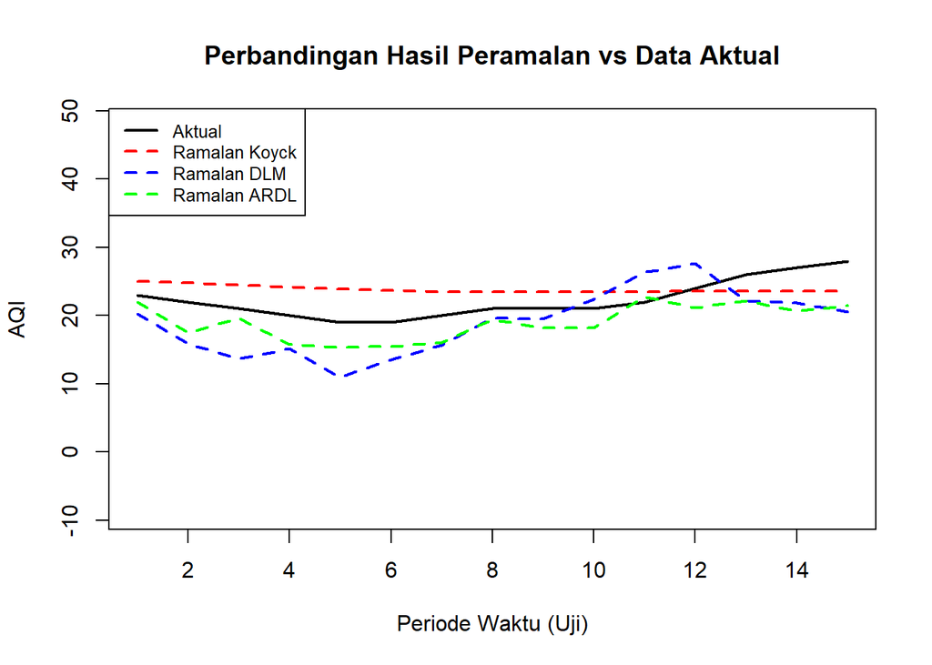

```r
plot(test$Yt, type = "l", col = "black", lwd = 2,
     main = "Perbandingan Hasil Peramalan vs Data Aktual",
     xlab = "Periode Waktu (Uji)", ylab = "AQI",
     ylim = c(min(c(test$Yt, fore.koyck$forecasts, fore.dlm$forecasts, fore.ardl$forecasts), na.rm=T) - 20,
              max(c(test$Yt, fore.koyck$forecasts, fore.dlm$forecasts, fore.ardl$forecasts), na.rm=T) + 20))

lines(fore.koyck$forecasts, col = "red", lty = 2, lwd = 2)
lines(fore.dlm$forecasts, col = "blue", lty = 2, lwd = 2)
lines(fore.ardl$forecasts, col = "green", lty = 2, lwd = 2)

legend("topleft",
       legend = c("Aktual", "Ramalan Koyck", "Ramalan DLM", "Ramalan ARDL"),
       col = c("black", "red", "blue", "green"),
       lty = c(1, 2, 2, 2), lwd = 2, cex = 0.8)
```